# Penanganan Autokorelasi (Cochrane-Orcutt dan Hildreth-Lu)

# 1 Library

```r
library(lmtest)
library(readxl)
library(orcutt)
```

# 2 Import Data

```r
dt <- read_excel("~/IPB Kuliah/Semester 5/MPDW/Pertemuan 3/IPM Samarinda 2010-2024.xlsx")
dt
```

```
## # A tibble: 15 × 2
##    Tahun   IPM
##    <dbl> <dbl>
##  1  2010  75.8
##  2  2011  77.0
##  3  2012  77.3
##  4  2013  77.8
##  5  2014  78.4
##  6  2015  78.7
##  7  2016  78.9
##  8  2017  79.5
##  9  2018  79.9
## 10  2019  80.2
## 11  2020  80.1
## 12  2021  80.8
## 13  2022  81.4
## 14  2023  82.3
## 15  2024  82.8
```

```r
# Konversi ke data time series tahunan
ipm_ts <- ts(dt$IPM, start = min(dt$Tahun), frequency = 1)
```

# 3 Plot IPM Samarinda

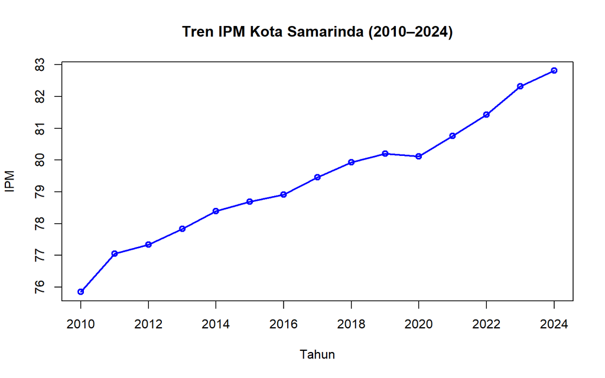

```r
plot(ipm_ts, type = "o", col = "blue", lwd = 2,
     main = "Tren IPM Kota Samarinda (2010–2024)",
     xlab = "Tahun", ylab = "IPM")
```

# Pemodelan Linier

```r
model_lm <- lm(IPM ~ Tahun, data = dt)
summary(model_lm)
```

```
##
## Call:
## lm(formula = IPM ~ Tahun, data = dt)
##
## Residuals:
##      Min       1Q   Median       3Q      Max
## -0.59961 -0.11187  0.08946  0.21168  0.36225
##
## Coefficients:
##               Estimate Std. Error t value Pr(>|t|)
## (Intercept) -797.05254   37.37160  -21.33 1.69e-11 ***
## Tahun          0.43454    0.01853   23.45 5.05e-12 ***
## ---
## Signif. codes:  0 '***' 0.001 '**' 0.01 '*' 0.05 '.' 0.1 ' ' 1
##
## Residual standard error: 0.31 on 13 degrees of freedom
## Multiple R-squared:  0.9769, Adjusted R-squared:  0.9751
## F-statistic:   550 on 1 and 13 DF,  p-value: 5.049e-12
```

# 4 Deteksi Autokorelasi

## 4.1 Uji Autokorelasi : Durbin Watson

```r
dwtest(model_lm)
```

```
##
##  Durbin-Watson test
##
## data:  model_lm
## DW = 1.0545, p-value = 0.00906
## alternative hypothesis: true autocorrelation is greater than 0
```

karena p-value < 0.05 → indikasi autokorelasi positif

## 4.2 Plot Residual terhadap Waktu

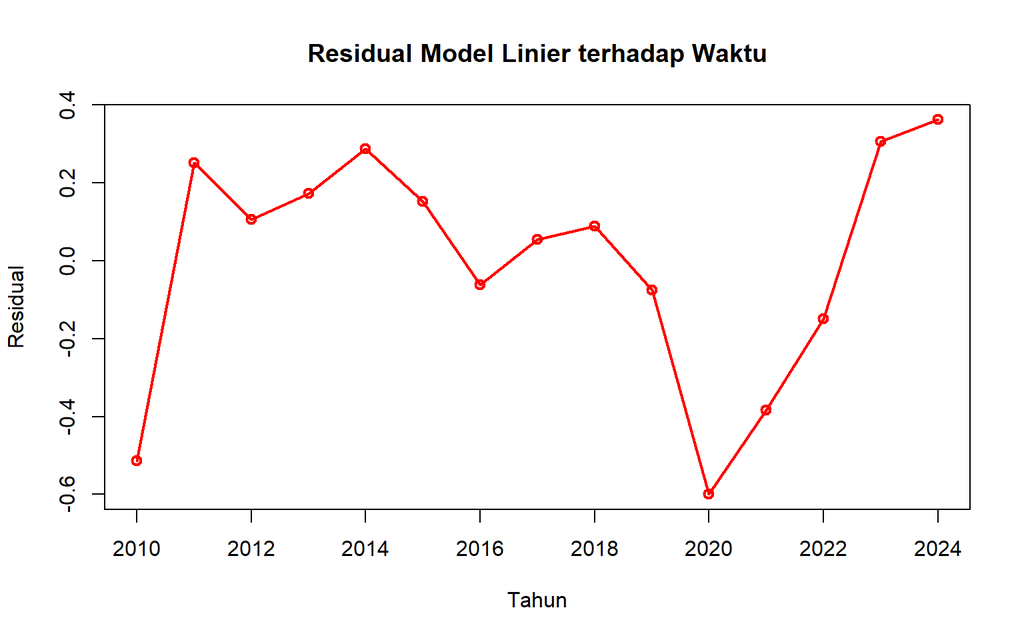

```r
resid_lm <- residuals(model_lm)

plot(dt$Tahun, resid_lm, type = "o", col = "red", lwd = 2,
     main = "Residual Model Linier terhadap Waktu",
     xlab = "Tahun", ylab = "Residual")
```

Berdasarkan visualisasi residual model linier terhadap waktu, terlihat pola naik-turun yang berurutan, yang mengindikasikan adanya autokorelasi secara visual.

## 4.3 Uji ACF dan PACF

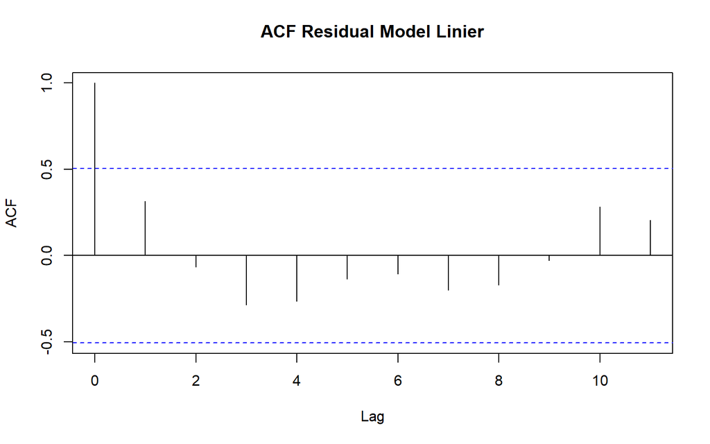

```r
# Konversi residual ke time series
resid_ts <- ts(resid_lm, start = min(dt$Tahun), frequency = 1)

# Plot ACF dan PACF
acf(resid_ts, main = "ACF Residual Model Linier")
```

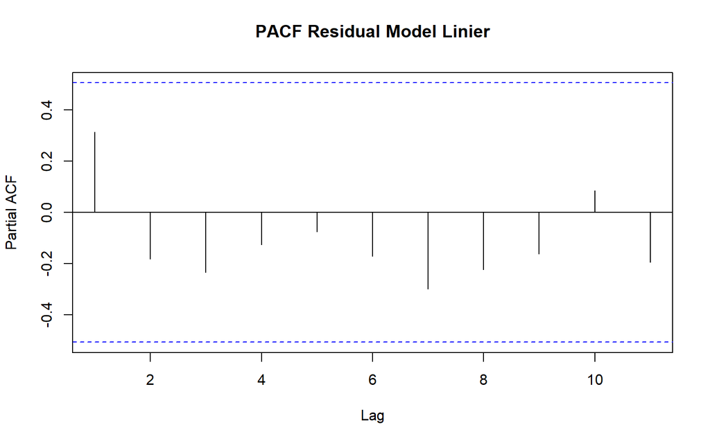

```r
pacf(resid_ts, main = "PACF Residual Model Linier")
```

Meskipun hasil uji ACF dan PACF tidak menunjukkan autokorelasi yang signifikan, uji Durbin-Watson dan pola fluktuatif pada residual secara visual mengindikasikan adanya potensi autokorelasi. Oleh karena itu, dilakukan penerapan metode Cochrane-Orcutt dan Hildreth-Lu sebagai pendekatan korektif untuk menguji efektivitas penanganan autokorelasi pada model.

# 5 Penanganan Autokorelasi

## 5.1 Cochrane-Orcutt

Dalam analisis ini digunakan fungsi cochrane.orcutt() dari package orcutt yang secara otomatis melakukan estimasi parameter autokorelasi (rho) dan transformasi variabel sesuai prosedur Cochrane-Orcutt. Meskipun tidak dilakukan transformasi manual seperti yang dijelaskan dalam ppt kuliah, fungsi ini telah mengimplementasikan prinsip yang sama secara komputasional.

```r
model_co <- cochrane.orcutt(model_lm)
summary(model_co)
```

```
## Call:
## lm(formula = IPM ~ Tahun, data = dt)
##
##                Estimate  Std. Error t value  Pr(>|t|)
## (Intercept) -757.689456   51.270033 -14.778 4.607e-09 ***
## Tahun          0.415064    0.025406  16.337 1.458e-09 ***
## ---
## Signif. codes:  0 '***' 0.001 '**' 0.01 '*' 0.05 '.' 0.1 ' ' 1
##
## Residual standard error: 0.255 on 12 degrees of freedom
## Multiple R-squared:  0.957 ,  Adjusted R-squared:  0.9534
## F-statistic: 266.9 on 1 and 12 DF,  p-value: < 1.458e-09
##
## Durbin-Watson statistic
## (original):    1.05455 , p-value: 9.06e-03
## (transformed): 1.09722 , p-value: 1.327e-02
```

```r
# Lihat nilai rho (estimasi autokorelasi)
model_co$rho
```

```
## [1] 0.3345172
```

```r
# Lihat model baru setelah koreksi
model_co$coefficients
```

```
##  (Intercept)        Tahun
## -757.6894564    0.4150636
```

Namun, untuk validasi lebih lanjut dilakukan dwtest lagi untuk model Cochrane-Orcutt

```r
dwtest(model_co)
```

```
##
##  Durbin-Watson test
##
## data:  model_co
## DW = 1.0972, p-value = 0.01327
## alternative hypothesis: true autocorrelation is greater than 0
```

Meskipun telah dilakukan koreksi autokorelasi dengan metode Cochrane-Orcutt, hasil uji Durbin-Watson menunjukkan nilai DW sebesar 1.0972 dengan p-value 0.01327. Hal ini mengindikasikan bahwa autokorelasi residual masih signifikan, sehingga model hasil koreksi belum sepenuhnya memenuhi asumsi independensi residual.

## 5.2 Hildreth-Lu

```r
# Simpan residual dan prediktor
resid_lm <- residuals(model_lm)
x <- dt$Tahun
y <- dt$IPM

# Fungsi untuk menghitung SSE berdasarkan nilai rho
sse_rho <- function(rho) {
  y_star <- y[-1] - rho * y[-length(y)]
  x_star <- x[-1] - rho * x[-length(x)]
  model_star <- lm(y_star ~ x_star)
  sum(residuals(model_star)^2)
}

# Cari nilai rho yang meminimalkan SSE
opt_rho <- optimize(sse_rho, interval = c(-1, 1))$minimum
opt_rho
```

```
## [1] 0.3345172
```

Estimasi rho sebesar 0.3345 dari metode Hildreth-Lu mengindikasikan autokorelasi positif sedang, sehingga dilakukan transformasi variabel untuk membentuk model koreksi.

```r
# Transformasi variabel dengan rho optimal
y_star <- y[-1] - opt_rho * y[-length(y)]
x_star <- x[-1] - opt_rho * x[-length(x)]

# Model Hildreth-Lu
model_hl <- lm(y_star ~ x_star)
summary(model_hl)
```

```
##
## Call:
## lm(formula = y_star ~ x_star)
##
## Residuals:
##      Min       1Q   Median       3Q      Max
## -0.58749 -0.12172  0.00772  0.11265  0.38240
##
## Coefficients:
##               Estimate Std. Error t value Pr(>|t|)
## (Intercept) -504.22930   34.11932  -14.78 4.61e-09 ***
## x_star         0.41506    0.02541   16.34 1.46e-09 ***
## ---
## Signif. codes:  0 '***' 0.001 '**' 0.01 '*' 0.05 '.' 0.1 ' ' 1
##
## Residual standard error: 0.255 on 12 degrees of freedom
## Multiple R-squared:  0.957,  Adjusted R-squared:  0.9534
## F-statistic: 266.9 on 1 and 12 DF,  p-value: 1.458e-09
```

```r
dwtest(model_hl)
```

```
##
##  Durbin-Watson test
##
## data:  model_hl
## DW = 1.0972, p-value = 0.01327
## alternative hypothesis: true autocorrelation is greater than 0
```

Hasil uji Durbin-Watson terhadap model Hildreth-Lu menunjukkan nilai DW sebesar 1.0972 dengan p-value 0.01327, yang mengindikasikan bahwa autokorelasi residual masih signifikan. Hal ini menunjukkan bahwa koreksi autokorelasi dengan metode Hildreth-Lu belum sepenuhnya efektif dalam menghilangkan keterkaitan antar residual.

# 6 Kesimpulan

Berdasarkan hasil uji Durbin-Watson, baik sebelum maupun sesudah koreksi, diketahui bahwa autokorelasi residual masih signifikan secara statistik. Nilai DW pada model awal sebesar 1.0545 (p-value = 0.00906), dan setelah koreksi dengan metode Cochrane-Orcutt maupun Hildreth-Lu, nilai DW hanya meningkat sedikit menjadi 1.0972 (p-value = 0.01327). Hal ini menunjukkan bahwa kedua metode belum mampu sepenuhnya menghilangkan autokorelasi.

Dengan demikian, model hasil koreksi belum sepenuhnya valid secara asumsi klasik regresi. Hal ini mengindikasikan bahwa pendekatan Cochrane-Orcutt dan Hildreth-Lu belum cukup efektif dalam menangani struktur autokorelasi pada data IPM Kota Samarinda. Oleh karena itu, diperlukan pendekatan alternatif, seperti model time series yang lebih kompleks (misalnya ARIMA), atau penambahan variabel yang dapat menjelaskan dinamika temporal secara lebih akurat.

# Penanganan Autokorelasi (Cochrane-Orcutt dan Hildreth-Lu)

# 1 Library

```r
library(lmtest)
library(readxl)
library(orcutt)
```

# 2 Import Data

```r
dt <- read_excel("~/IPB Kuliah/Semester 5/MPDW/Pertemuan 3/IPM Samarinda 2010-2024.xlsx")
dt
```

```
## # A tibble: 15 × 2
##    Tahun   IPM
##    <dbl> <dbl>
##  1  2010  75.8
##  2  2011  77.0
##  3  2012  77.3
##  4  2013  77.8
##  5  2014  78.4
##  6  2015  78.7
##  7  2016  78.9
##  8  2017  79.5
##  9  2018  79.9
## 10  2019  80.2
## 11  2020  80.1
## 12  2021  80.8
## 13  2022  81.4
## 14  2023  82.3
## 15  2024  82.8
```

```r
# Konversi ke data time series tahunan
ipm_ts <- ts(dt$IPM, start = min(dt$Tahun), frequency = 1)
```

# 3 Plot IPM Samarinda

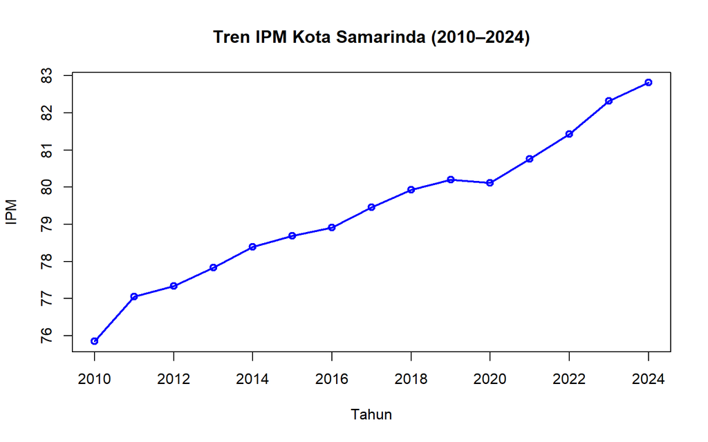

```r
plot(ipm_ts, type = "o", col = "blue", lwd = 2,
     main = "Tren IPM Kota Samarinda (2010–2024)",
     xlab = "Tahun", ylab = "IPM")
```

# Pemodelan Linier

```r
model_lm <- lm(IPM ~ Tahun, data = dt)
summary(model_lm)
```

```
##
## Call:
## lm(formula = IPM ~ Tahun, data = dt)
##
## Residuals:
##      Min       1Q   Median       3Q      Max
## -0.59961 -0.11187  0.08946  0.21168  0.36225
##
## Coefficients:
##               Estimate Std. Error t value Pr(>|t|)
## (Intercept) -797.05254   37.37160  -21.33 1.69e-11 ***
## Tahun          0.43454    0.01853   23.45 5.05e-12 ***
## ---
## Signif. codes:  0 '***' 0.001 '**' 0.01 '*' 0.05 '.' 0.1 ' ' 1
##
## Residual standard error: 0.31 on 13 degrees of freedom
## Multiple R-squared:  0.9769, Adjusted R-squared:  0.9751
## F-statistic:   550 on 1 and 13 DF,  p-value: 5.049e-12
```

# 4 Deteksi Autokorelasi

## 4.1 Uji Autokorelasi : Durbin Watson

```r
dwtest(model_lm)
```

```
##
##  Durbin-Watson test
##
## data:  model_lm
## DW = 1.0545, p-value = 0.00906
## alternative hypothesis: true autocorrelation is greater than 0
```

karena p-value < 0.05 → indikasi autokorelasi positif

## 4.2 Plot Residual terhadap Waktu

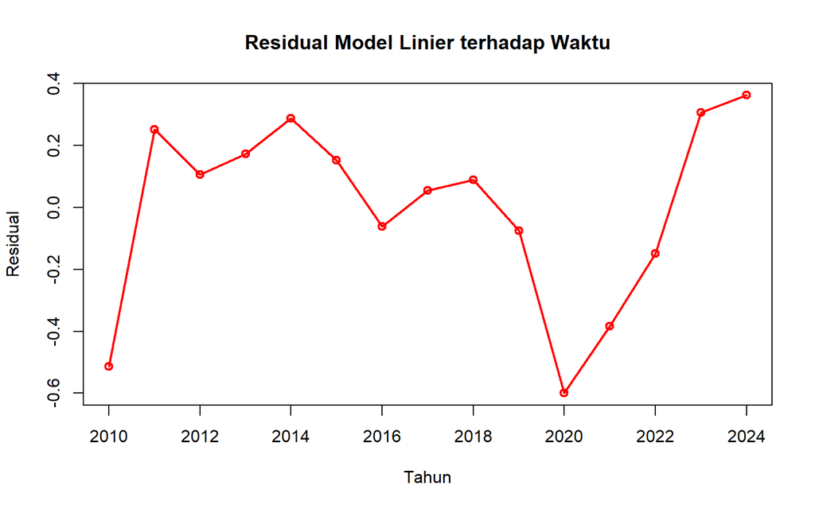

```r
resid_lm <- residuals(model_lm)

plot(dt$Tahun, resid_lm, type = "o", col = "red", lwd = 2,
     main = "Residual Model Linier terhadap Waktu",
     xlab = "Tahun", ylab = "Residual")
```

Berdasarkan visualisasi residual model linier terhadap waktu, terlihat pola naik-turun yang berurutan, yang mengindikasikan adanya autokorelasi secara visual.

## 4.3 Uji ACF dan PACF

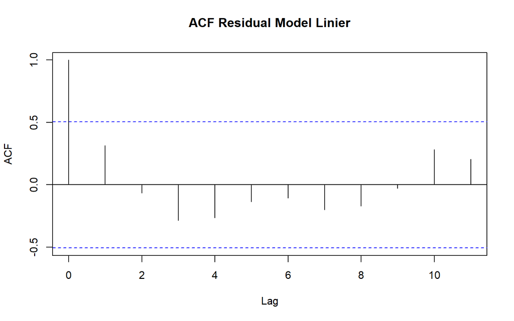

```r
# Konversi residual ke time series
resid_ts <- ts(resid_lm, start = min(dt$Tahun), frequency = 1)

# Plot ACF dan PACF
acf(resid_ts, main = "ACF Residual Model Linier")
```

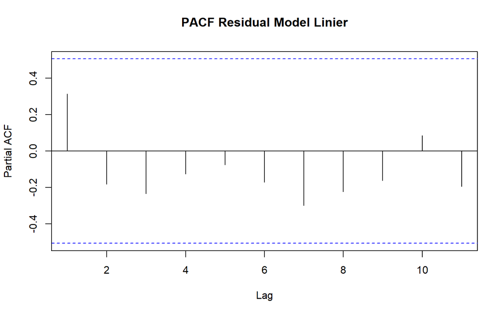

```r
pacf(resid_ts, main = "PACF Residual Model Linier")
```

Meskipun hasil uji ACF dan PACF tidak menunjukkan autokorelasi yang signifikan, uji Durbin-Watson dan pola fluktuatif pada residual secara visual mengindikasikan adanya potensi autokorelasi. Oleh karena itu, dilakukan penerapan metode Cochrane-Orcutt dan Hildreth-Lu sebagai pendekatan korektif untuk menguji efektivitas penanganan autokorelasi pada model.

# 5 Penanganan Autokorelasi

## 5.1 Cochrane-Orcutt

Dalam analisis ini digunakan fungsi cochrane.orcutt() dari package orcutt yang secara otomatis melakukan estimasi parameter autokorelasi (rho) dan transformasi variabel sesuai prosedur Cochrane-Orcutt. Meskipun tidak dilakukan transformasi manual seperti yang dijelaskan dalam ppt kuliah, fungsi ini telah mengimplementasikan prinsip yang sama secara komputasional.

```r
model_co <- cochrane.orcutt(model_lm)
summary(model_co)
```

```
## Call:
## lm(formula = IPM ~ Tahun, data = dt)
##
##                Estimate  Std. Error t value  Pr(>|t|)
## (Intercept) -757.689456   51.270033 -14.778 4.607e-09 ***
## Tahun          0.415064    0.025406  16.337 1.458e-09 ***
## ---
## Signif. codes:  0 '***' 0.001 '**' 0.01 '*' 0.05 '.' 0.1 ' ' 1
##
## Residual standard error: 0.255 on 12 degrees of freedom
## Multiple R-squared:  0.957 ,  Adjusted R-squared:  0.9534
## F-statistic: 266.9 on 1 and 12 DF,  p-value: < 1.458e-09
##
## Durbin-Watson statistic
## (original):    1.05455 , p-value: 9.06e-03
## (transformed): 1.09722 , p-value: 1.327e-02
```

```r
# Lihat nilai rho (estimasi autokorelasi)
model_co$rho
```

```
## [1] 0.3345172
```

```r
# Lihat model baru setelah koreksi
model_co$coefficients
```

```
##  (Intercept)        Tahun
## -757.6894564    0.4150636
```

Namun, untuk validasi lebih lanjut dilakukan dwtest lagi untuk model Cochrane-Orcutt

```r
dwtest(model_co)
```

```
##
##  Durbin-Watson test
##
## data:  model_co
## DW = 1.0972, p-value = 0.01327
## alternative hypothesis: true autocorrelation is greater than 0
```

Meskipun telah dilakukan koreksi autokorelasi dengan metode Cochrane-Orcutt, hasil uji Durbin-Watson menunjukkan nilai DW sebesar 1.0972 dengan p-value 0.01327. Hal ini mengindikasikan bahwa autokorelasi residual masih signifikan, sehingga model hasil koreksi belum sepenuhnya memenuhi asumsi independensi residual.

## 5.2 Hildreth-Lu

```r
# Simpan residual dan prediktor
resid_lm <- residuals(model_lm)
x <- dt$Tahun
y <- dt$IPM

# Fungsi untuk menghitung SSE berdasarkan nilai rho
sse_rho <- function(rho) {
  y_star <- y[-1] - rho * y[-length(y)]
  x_star <- x[-1] - rho * x[-length(x)]
  model_star <- lm(y_star ~ x_star)
  sum(residuals(model_star)^2)
}

# Cari nilai rho yang meminimalkan SSE
opt_rho <- optimize(sse_rho, interval = c(-1, 1))$minimum
opt_rho
```

```
## [1] 0.3345172
```

Estimasi rho sebesar 0.3345 dari metode Hildreth-Lu mengindikasikan autokorelasi positif sedang, sehingga dilakukan transformasi variabel untuk membentuk model koreksi.

```r
# Transformasi variabel dengan rho optimal
y_star <- y[-1] - opt_rho * y[-length(y)]
x_star <- x[-1] - opt_rho * x[-length(x)]

# Model Hildreth-Lu
model_hl <- lm(y_star ~ x_star)
summary(model_hl)
```

```
##
## Call:
## lm(formula = y_star ~ x_star)
##
## Residuals:
##      Min       1Q   Median       3Q      Max
## -0.58749 -0.12172  0.00772  0.11265  0.38240
##
## Coefficients:
##               Estimate Std. Error t value Pr(>|t|)
## (Intercept) -504.22930   34.11932  -14.78 4.61e-09 ***
## x_star         0.41506    0.02541   16.34 1.46e-09 ***
## ---
## Signif. codes:  0 '***' 0.001 '**' 0.01 '*' 0.05 '.' 0.1 ' ' 1
##
## Residual standard error: 0.255 on 12 degrees of freedom
## Multiple R-squared:  0.957,  Adjusted R-squared:  0.9534
## F-statistic: 266.9 on 1 and 12 DF,  p-value: 1.458e-09
```

```r
dwtest(model_hl)
```

```
##
##  Durbin-Watson test
##
## data:  model_hl
## DW = 1.0972, p-value = 0.01327
## alternative hypothesis: true autocorrelation is greater than 0
```

Hasil uji Durbin-Watson terhadap model Hildreth-Lu menunjukkan nilai DW sebesar 1.0972 dengan p-value 0.01327, yang mengindikasikan bahwa autokorelasi residual masih signifikan. Hal ini menunjukkan bahwa koreksi autokorelasi dengan metode Hildreth-Lu belum sepenuhnya efektif dalam menghilangkan keterkaitan antar residual.

# 6 Kesimpulan

Berdasarkan hasil uji Durbin-Watson, baik sebelum maupun sesudah koreksi, diketahui bahwa autokorelasi residual masih signifikan secara statistik. Nilai DW pada model awal sebesar 1.0545 (p-value = 0.00906), dan setelah koreksi dengan metode Cochrane-Orcutt maupun Hildreth-Lu, nilai DW hanya meningkat sedikit menjadi 1.0972 (p-value = 0.01327). Hal ini menunjukkan bahwa kedua metode belum mampu sepenuhnya menghilangkan autokorelasi.

Dengan demikian, model hasil koreksi belum sepenuhnya valid secara asumsi klasik regresi. Hal ini mengindikasikan bahwa pendekatan Cochrane-Orcutt dan Hildreth-Lu belum cukup efektif dalam menangani struktur autokorelasi pada data IPM Kota Samarinda. Oleh karena itu, diperlukan pendekatan alternatif, seperti model time series yang lebih kompleks (misalnya ARIMA), atau penambahan variabel yang dapat menjelaskan dinamika temporal secara lebih akurat.